# Transparency Linguistics Analysis

Erin M. Buchanan

Last Knitted 2022-07-21

## Analysis Plan

For each measured variable, we will report raw numbers and percentages in each response category. Additional analyses will be exploratory; we are not conducting confirmatory tests of any a priori hypotheses.

## Libraries

```r
library(rio)
library(dplyr)
```

```r
library(stringi)
library(tidyr)
library(psych)
library(ggplot2)
library(maps)
library(countrycode)
library(webr)
library(patchwork)
```

## Get the Data

```r
#DF <- import("coded_responses.xlsx")
DF <- import("../analysis/coded_responses.xlsx")
# names(DF)

# column 35 is empty
DF <- DF %>% select(-`...35`)

# take out pilot testing 2021-05-21 04:12:04 and before
DF <- DF %>% filter(Timestamp > as.POSIXct("2021-05-22"))

# these names are descriptive but no fun to type
colnames(DF) <- c("TimeStamp", "TimeStarted", "DateStarted",
                  "Coder", "ArticleID", "ArticleIssues", "ArticleLanguage",
                  "JIF", "StudyType", "PreReg", "PreRegWhere", "PreRegAccess",
                  "PreRegAspects", "RawData", "RawDataAvl", "RawDataWhere",
                  "RawDataAccess", "RawDataDocument", "ProcessData",
                  "ProcessDataWhere", "ProcessDataAccess", "ProcessDataDocument",
                  "AnalysisScript", "AnalysisScriptWhere", "AnalysisScriptAccess",
                  "Materials", "MaterialsWhere", "MaterialsAccess", "COI",
                  "Replication", "OA", "TimeEnded", "DateEnded", "CountryAuthor",
                  "EmpiricalStudyData", "JIFYear")

# list of information from scopus
#prescreenDF <- import("../Prescreening/prescreening_round1.csv")
#prescreenDF2 <- import("../data/prescreening_list_2021-07-04.txt")

prescreenDF <- import("../Prescreening/prescreening_round1.csv")
prescreenDF2 <- import("../data/prescreening_list_2021-07-04.txt")

# deal with the duplicate ID issue
# we didn't code this one but we did code the other one
# as per github page (pulled original number)
prescreenDF$ID[prescreenDF$Title == "Quantified epistemic logics for reasoning about knowledge in multi-agent systems"] <- "e754dd1b"

# import the OA code
#openaccessDF <- import("OA_Coding_10_2021.xlsx") %>% select(-`...9`) %>% filter(!is.na(row_num))
openaccessDF <- import("../analysis/OA_Coding_10_2021.xlsx") %>% select(-`...9`) %>% filter(!is.na(row_num))
# import code on who was doing what to check all are done
#coder1 <- import("../data/randomized_prescreen_df_2021_10_21.csv")
#coder2 <- import("../data/randomized_prescreen_df_rnd2_2022_03_14.csv")

coder1 <- import("../data/randomized_prescreen_df_2021_10_21.csv")
coder2 <- import("../data/randomized_prescreen_df_rnd2_2022_03_14.csv")
```

### Clean Up Data

```r
# merge information about publication year, field, pre versus post
DF2 <- DF %>%
  # year, year label, DOI
  left_join(
  (prescreenDF %>% select(ID, Year, year_split, clickable_doi, first_code_include)),
  by = c("ArticleID" = "ID")
)

# fix the coding issues
A_ID_fix <- DF2 %>% filter(is.na(year_split)) %>% select(ArticleID)
A_ID_fix <- as.vector(A_ID_fix$ArticleID)
A_ID_fix <- paste0("\\b", A_ID_fix, "\\b")

A_ID_fixed <- c("96498326", "9586644", "86897574", "35147373",
                "34004670", "33442876", "53780209", "15561653",
                "4.16E+06", "98056778", "74a007fe", "9923056",
                "67395332", "5.84E+59", "98963718", "20880301",
                "84326216", "30630572", "8.86E+11", "15561653",
                "239b8bc4", "98963718", "86897574")

length(A_ID_fix) == length(A_ID_fixed)
```

```
## [1] TRUE
```

```r
DF$ArticleID <- stri_replace_all_regex(str = DF$ArticleID,
                             pattern = A_ID_fix,
                             replacement = A_ID_fixed,
                             vectorize_all = FALSE)

# fix some other fun quirks
# i checked these were not also in coder 2
coder1$ID[coder1$ID == "8.86e+11"] <- "8.86E+11"
coder1$ID[coder1$ID == "5.84e+59"] <- "5.84E+59"
coder1$ID[coder1$ID == "4160000"] <- "4.16E+06"

# now really merge once IDs are fixed
DF2 <- DF %>% left_join(
  (prescreenDF %>% select(ID, Year, year_split, clickable_doi)),
  by = c("ArticleID" = "ID")
) %>%
  # coder assignments
  full_join(
  (coder1 %>% select(ID, coder)),
  by = c("ArticleID" = "ID")
) %>%
  full_join(
  (coder2 %>% select(ID, round2_coder)),
  by = c("ArticleID" = "ID")
  ) %>%
  # article journal, source title
  left_join(
    (prescreenDF2 %>% select(ID, Source.title)),
     by = c("ArticleID" = "ID")
  )

# look for missing articles
DF2 %>% filter(is.na(TimeStamp)) %>% select(coder, ArticleID)
```

```
##   coder ArticleID
## 1    tr  0e3e42b8
```

```r
# look at duplicates by the same person
dup_IDs <- DF2 %>% filter(duplicated(DF2 %>% select(ArticleID, Coder))) %>% pull(ArticleID)

DF2 %>% filter(ArticleID %in% dup_IDs)
```

```
##             TimeStamp         TimeStarted DateStarted Coder ArticleID
## 1 2021-11-01 12:29:40 1899-12-31 12:27:00  2021-11-01    TR  64cf897b
## 2 2021-11-01 12:35:18 1899-12-31 12:32:00  2021-11-01    TR  64cf897b
## 3 2021-11-01 16:21:25 1899-12-31 16:18:00  2021-11-01    TR  cc497581
## 4 2021-11-02 11:19:18 1899-12-31 11:16:00  2021-11-02    TR  cc497581
## 5 2021-11-09 16:47:53 1899-12-31 15:45:00  2021-11-09    LK  7ec4eaeb
## 6 2021-11-10 09:58:20 1899-12-31 08:55:00  2021-11-10    LK  7ec4eaeb
##         ArticleIssues  ArticleLanguage   JIF
## 1 There are no issues          unclear 0.809
## 2 There are no issues        universal 0.814
## 3 There are no issues cross linguistic 0.857
## 4 There are no issues          unclear 0.857
## 5 There are no issues cross linguistic    NA
## 6 There are no issues cross linguistic    NA
##                                                                                                                                  StudyType
```

[output cut: 62 more lines]

```r
# now, what I did was go to the git issue
# https://github.com/troettge/Transparency-Ling/issues/24
# looked at the articles each person did
# figured out which two were copy paste article errors for TR
# LK appears to be a real duplicate
# TR cc497581 also appears to be a real duplicate

# 0e3e42b8 comes after 64cf897b
DF$ArticleID[DF$ArticleID == "64cf897b"][2] <- "0e3e42b8"

# remove real duplicates
DF <- DF %>%
  filter(!duplicated(DF %>% select(ArticleID, Coder)))

# final data
DF <- DF %>% left_join(
  (prescreenDF %>% select(ID, Year, year_split, clickable_doi)),
  by = c("ArticleID" = "ID")
) %>%
  # coder assignments
  full_join(
  (coder1 %>% select(ID, coder)),
  by = c("ArticleID" = "ID")
) %>%
  full_join(
  (coder2 %>% select(ID, round2_coder)),
  by = c("ArticleID" = "ID")
  ) %>%
  # article journal, source title
  left_join(
    (prescreenDF2 %>% select(ID, Source.title)),
     by = c("ArticleID" = "ID")
  )
```

### Round 2 Coding

Figure out what to check and export that file for the second coding check.

```r
DF_Second <- DF %>%
      filter(!is.na(round2_coder)) %>%
      select(-c(TimeStamp, TimeStarted, DateStarted, OA,
                TimeEnded, DateEnded, Year, year_split, clickable_doi,
                coder, Source.title, round2_coder)) %>%
      group_by(ArticleID) %>%
      mutate(coder_num = paste0("coder_", row_number())) %>%
      ungroup() %>%
      pivot_longer(cols = -c(ArticleID, coder_num, Coder)) %>%
      pivot_wider(id_cols = c(ArticleID, name),
                  names_from = coder_num,
                  values_from = c(value, Coder))

  # original code that excluded NA values and matches #
  # this excluded things I didn't mean to that #
  # were potentially not matches #
  # filter(!is.na(easy_screen)) %>%
  # filter(easy_screen == F) %>%
  # mutate(check = rep(c("EB", "KC", "IC", "CH"), length.out = nrow(.)))

#export(DF_Second, "second_coder_check.csv", row.names = F)
export(DF_Second, "../analysis/second_coder_check.csv", row.names = F)
```

Import and examine the results from the second coding check.

First, EMB noticed that she did not print out the article mismatches for review that had one NA value and one real value, which would generally be a mismatch. Given the group discussion described below and a few apparent miscodings, EMB recoded all the mismatches as described: (note that the original coding is avaliable in the excel document imported below second_coder_done.xlsx on a second sheet)

- The “unclear” category was added to indicate it was unclear if it was a mismatch because the person may have skipped answering these questions if they did not think the article was about language or did not have access. Therefore, all articles with one coder NA value and one coder real text was coded as Unclear.
- A not available and not applicable was coded as a match.
- A partial category was added for answers that overlapped but weren’t exactly the same.

We also separately coded JIF because only a few members had access to the information in a specialized database.

```r
#DF_Second_import <- import("second_coder_done.xlsx")
DF_Second_import <- import("../analysis/second_coder_done.xlsx")


DF_Second_match <- DF %>% filter(!is.na(round2_coder)) %>%
  select(-c(TimeStamp, TimeStarted, DateStarted, OA,
            TimeEnded, DateEnded, Year, year_split, clickable_doi,
            coder, Source.title, round2_coder)) %>%
  group_by(ArticleID) %>%
  mutate(coder_num = paste0("coder_", row_number())) %>%
  ungroup() %>%
  select(-Coder) %>%
  pivot_longer(cols = -c(ArticleID, coder_num)) %>%
  pivot_wider(id_cols = c(ArticleID, name),
              names_from = coder_num,
              values_from = value) %>%
  mutate(easy_screen = coder_1 == coder_2) %>%
  left_join((DF_Second_import %>% select(ArticleID, answer, name, corrected_answer)),
            by = c("ArticleID" = "ArticleID",
                   "name" = "name"))

# comparison table of screenings (easy is exact match)
table("easy" = DF_Second_match$easy_screen,
      "coded" = DF_Second_match$answer,
      useNA = "ifany")
```

```
##        coded
## easy    FALSE Partial TRUE Unclear
##   FALSE   210      45   58       2
##   TRUE      0       0  925       0
##   <NA>      0       0 1727     393
```

```r
# overall agreement
table(DF_Second_match$answer, useNA = "ifany")
```

```
##
##   FALSE Partial    TRUE Unclear
##     210      45    2710     395
```

```r
# table of agreement before exclusion of first question mismatches
table(DF_Second_match$answer,
      DF_Second_match$name,
      useNA = "ifany") / 120 * 100
```

```
##
##           AnalysisScript AnalysisScriptAccess AnalysisScriptWhere ArticleIssues
##   FALSE        0.8333333            0.0000000           0.0000000    18.3333333
##   Partial      0.0000000            0.0000000           0.0000000     0.0000000
##   TRUE        85.8333333           98.3333333          98.3333333    81.6666667
##   Unclear     13.3333333            1.6666667           1.6666667     0.0000000
##
##           ArticleLanguage         COI CountryAuthor EmpiricalStudyData
##   FALSE        10.0000000   4.1666667     6.6666667         13.3333333
##   Partial      11.6666667   0.0000000     0.8333333         10.8333333
##   TRUE         60.0000000  78.3333333    75.0000000         60.8333333
##   Unclear      18.3333333  17.5000000    17.5000000         15.0000000
##
##                   JIF     JIFYear   Materials MaterialsAccess MaterialsWhere
##   FALSE    69.1666667  10.8333333  10.8333333       0.0000000      0.8333333
##   Partial   0.0000000   0.0000000   0.0000000       0.0000000      0.0000000
##   TRUE     13.3333333  35.0000000  75.8333333      86.6666667     85.8333333
##   Unclear  17.5000000  54.1666667  13.3333333      13.3333333     13.3333333
##
##                PreReg PreRegAccess PreRegAspects PreRegWhere ProcessData
##   FALSE     0.0000000    0.0000000     0.0000000   0.0000000   2.5000000
##   Partial   0.0000000    0.0000000     0.0000000   0.0000000   0.0000000
##   TRUE     86.6666667  100.0000000   100.0000000 100.0000000  78.3333333
##   Unclear  13.3333333    0.0000000     0.0000000   0.0000000  19.1666667
##
##           ProcessDataAccess ProcessDataDocument ProcessDataWhere     RawData
##   FALSE           0.8333333           0.8333333        0.0000000   5.0000000
##   Partial         0.0000000           0.0000000        0.0000000  13.3333333
##   TRUE           96.6666667          96.6666667       97.5000000  68.3333333
##   Unclear         2.5000000           2.5000000        2.5000000  13.3333333
##
##           RawDataAccess  RawDataAvl RawDataDocument RawDataWhere Replication
##   FALSE       0.8333333   9.1666667       3.3333333    3.3333333   1.6666667
##   Partial     0.8333333   0.0000000       0.0000000    0.0000000   0.0000000
##   TRUE       86.6666667  77.5000000      84.1666667   85.8333333  85.0000000
##   Unclear    11.6666667  13.3333333      12.5000000   10.8333333  13.3333333
##
##             StudyType
##   FALSE     2.5000000
##   Partial   0.0000000
##   TRUE     80.0000000
##   Unclear  17.5000000
```

Overall these results indicate a need to examine:

- Articles Issues (this was true before recoding)
- JIF was recoded (see below)

In a group discussion, we first discovered that the “mismatches” were often from one person indicating they did not have access to the article or disagreeing over if the article was about language. This first question would then lead to all other questions being in disagreement (and likely the unclear category mentioned above - therefore this was a problem in the `ArticleIssues` column).

Since the goal was to reach 250 articles in each pre and post era, we excluded all articles that were a mismatch because of these two issues (did not have access, article about language). We then recalculated the agreement statistics for the double coded articles in which both articles were actually coded.

```r
# print out articles that match
agree_list <- DF_Second_match %>%
  filter(answer == TRUE) %>%
  filter(name == "ArticleIssues") %>%
  pull(ArticleID)

length(agree_list)
```

```
## [1] 98
```

```r
# create a DF of just ones that agree past Article Issues
DF_Second_match_agree <- DF_Second_match %>% filter(ArticleID %in% agree_list)

# now examine for mismatches
table(DF_Second_match_agree$answer,
      DF_Second_match_agree$name,
      useNA = "ifany") / 98 * 100
```

```
##
##           AnalysisScript AnalysisScriptAccess AnalysisScriptWhere ArticleIssues
##   FALSE         1.020408             0.000000            0.000000      0.000000
##   Partial       0.000000             0.000000            0.000000      0.000000
##   TRUE         95.918367            97.959184           97.959184    100.000000
##   Unclear       3.061224             2.040816            2.040816      0.000000
##
##           ArticleLanguage        COI CountryAuthor EmpiricalStudyData
##   FALSE         12.244898   5.102041      8.163265          16.326531
##   Partial       14.285714   0.000000      1.020408          13.265306
##   TRUE          72.448980  94.897959     90.816327          65.306122
##   Unclear        1.020408   0.000000      0.000000           5.102041
##
##                  JIF    JIFYear  Materials MaterialsAccess MaterialsWhere
##   FALSE    83.673469  13.265306  13.265306        0.000000       1.020408
##   Partial   0.000000   0.000000   0.000000        0.000000       0.000000
##   TRUE     16.326531  29.591837  83.673469       85.714286      84.693878
##   Unclear   0.000000  57.142857   3.061224       14.285714      14.285714
##
##               PreReg PreRegAccess PreRegAspects PreRegWhere ProcessData
##   FALSE     0.000000     0.000000      0.000000    0.000000    3.061224
##   Partial   0.000000     0.000000      0.000000    0.000000    0.000000
##   TRUE     96.938776   100.000000    100.000000  100.000000   86.734694
##   Unclear   3.061224     0.000000      0.000000    0.000000   10.204082
##
##           ProcessDataAccess ProcessDataDocument ProcessDataWhere    RawData
##   FALSE            1.020408            1.020408         0.000000   6.122449
##   Partial          0.000000            0.000000         0.000000  16.326531
##   TRUE            95.918367           95.918367        96.938776  74.489796
##   Unclear          3.061224            3.061224         3.061224   3.061224
##
##           RawDataAccess RawDataAvl RawDataDocument RawDataWhere Replication
##   FALSE        1.020408  11.224490        4.081633     4.081633    2.040816
##   Partial      1.020408   0.000000        0.000000     0.000000    0.000000
##   TRUE        84.693878  85.714286       81.632653    83.673469   94.897959
##   Unclear     13.265306   3.061224       14.285714    12.244898    3.061224
##
##            StudyType
##   FALSE     3.061224
##   Partial   0.000000
##   TRUE     96.938776
##   Unclear   0.000000
```

After excluding articles that did not agree on the first item (and recoding above), we found that coders appeared to partially to completely agree at our threshold level.

### Number of Articles

```r
# make DF that's not the second coding
# break in data here 2022-03-10 17:13:23
DF <- DF %>% filter(TimeStamp < as.POSIXct("2022-03-14"))

# did we reach our goal?
table(DF$ArticleIssues, DF$year_split, useNA = "ifany")
```

```
##
##                                                                                                                                                    After-OS
##   Article is not about language                                                                                                                          31
##   Article is not in English                                                                                                                               0
##   Article published in 2011                                                                                                                               1
##   Article published in 2014                                                                                                                               1
##   Article published in 2017?                                                                                                                              1
##   I don't have access to the full text                                                                                                                    7
##   There are no issues                                                                                                                                   258
##   This article seems to be more about education (in bilingual contexts) than about language. But it has been pre-screened, so not sure about that.        0
##
##                                                                                                                                                    Pre-OS
##   Article is not about language                                                                                                                        27
##   Article is not in English                                                                                                                             1
##   Article published in 2011                                                                                                                             0
##   Article published in 2014                                                                                                                             0
##   Article published in 2017?                                                                                                                            0
##   I don't have access to the full text                                                                                                                  6
##   There are no issues                                                                                                                                 265
##   This article seems to be more about education (in bilingual contexts) than about language. But it has been pre-screened, so not sure about that.      1
```

```r
# table of double match
  #grab all articles that weren't double coded
  not_double <- DF %>% filter(!(ArticleID %in% DF_Second_match$ArticleID)) %>% pull(ArticleID)

DF_agree <- DF %>% filter(ArticleID %in% c(not_double, agree_list))
table(DF_agree$ArticleIssues, DF_agree$year_split, useNA = "ifany")
```

```
##
##                                                                                                                                                    After-OS
##   Article is not about language                                                                                                                          28
##   Article is not in English                                                                                                                               0
##   Article published in 2011                                                                                                                               1
##   Article published in 2014                                                                                                                               1
##   Article published in 2017?                                                                                                                              1
##   I don't have access to the full text                                                                                                                    6
##   There are no issues                                                                                                                                   251
##   This article seems to be more about education (in bilingual contexts) than about language. But it has been pre-screened, so not sure about that.        0
##
##                                                                                                                                                    Pre-OS
##   Article is not about language                                                                                                                        20
##   Article is not in English                                                                                                                             1
##   Article published in 2011                                                                                                                             0
##   Article published in 2014                                                                                                                             0
##   Article published in 2017?                                                                                                                            0
##   I don't have access to the full text                                                                                                                  4
##   There are no issues                                                                                                                                 263
##   This article seems to be more about education (in bilingual contexts) than about language. But it has been pre-screened, so not sure about that.      1
```

### Merge Partial/Unclear Answers

```r
# don't judge me on the loop ok
#DF_fix <- import("coder_abritration.xlsx") %>%
DF_fix <- import("../analysis/coder_abritration.xlsx") %>%
  filter(include == "included") %>%
  filter(!is.na(corrected_answer))

for (i in 1:nrow(DF_fix)){
  DF_agree[
    DF_agree$ArticleID == DF_fix$ArticleID[i], # article match
    DF_fix$name[i] # variable match
    ] <- DF_fix$corrected_answer[i]
}
```

```r
# rename DF to ensure match to rest of code
DF <- DF_agree
```

The following sections are in order of our preregistered plan: https://osf.io/j2q5p

## Article Characteristics

- Coder instructions: To identify journal impact factors use the Thomson Reuters Journal Citation Reports (https://jcr.clarivate.com/). For the question about the country, check the institutional affiliation of the corresponding author. If there are multiple corresponding authors, choose the first. If no corresponding author is identified, choose the first. If there are multiple affiliations for the selected author, choose the first. For the questions about study design, examine the title, abstract, and if necessary the methods section, to establish the study characteristics.

### Publication Information

- Publication year
  - Derived from Scopus meta-data
- Field
  - Derived from Scopus meta-data

```r
#DF$Year[DF$ArticleID == "795dfcd3"] <- 2008
table(DF$Year, useNA = "ifany")
```

```
##
## 2008 2009 2018 2019
##  149  140  132  156
```

```r
DF$Source.title[DF$ArticleID == "9586644"] <- "Artificial Intelligence Review"
DF$Source.title[DF$ArticleID == "4.16E+06"] <- "Reading & Writing Quarterly"
DF$Source.title[DF$ArticleID == "9923056"] <- "Applied Linguistics"
DF$Source.title[DF$ArticleID == "5.84E+59"] <- "Language, Culture and Curriculum"
DF$Source.title[DF$ArticleID == "8.86E+11"] <- "International Journal of Lexicography"

table(DF$Source.title, useNA = "ifany")
```

```
##
##                                            3L: Language, Linguistics, Literature
##                                                                                2
##                                                    Across Languages and Cultures
##                                                                                2
##                                                      Acta Linguistica Hafniensia
##                                                                                1
##                                                                      AILA Review
##                                                                                1
##                                                     Altorientalische Forschungen
##                                                                                1
##                                    American Journal of Speech-Language Pathology
##                                                                                2
##                                                                  American Speech
##                                                                                1
##                                                                        Ampersand
##                                                                                1
##                                                      Anthropological Linguistics
##                                                                                1
##                                                                      Aphasiology
##                                                                                7
##                                                              Applied Linguistics
##                                                                                4
##                                                        Applied Psycholinguistics
##                                                                                5
##                                                                    Argumentation
##                                                                                1
##                                                          Artificial Intelligence
##                                                                                1
##                                                   Artificial Intelligence Review
##                                                                                2
##                                                                Asian EFL Journal
##                                                                                2
##                                                                  Asian Englishes
##                                                                                1
##                                                                Asian ESP Journal
##                                                                                1
##                   Asian-Pacific Journal of Second and Foreign Language Education
##                                                                                2
##                                                                Assessing Writing
```

[output cut: 484 more lines]

```
##                                                                                1
##                                         Transactions of the Philological Society
##                                                                                2
##                                                                 Turkic Languages
##                                                                                1
##                                                 Western Journal of Communication
##                                                                                1
##                                                                             Word
##                                                                                1
##                                                                  World Englishes
##                                                                                3
##                                                    Written Language and Literacy
##                                                                                2
##                                                                         XLinguae
##                                                                                2
```

```r
# how many different journals in each split
length(unique(DF$Source.title))
```

```
## [1] 269
```

```r
DF %>%
  group_by(year_split) %>%
  summarize(n_distinct(Source.title))
```

```
## # A tibble: 2 × 2
##   year_split `n_distinct(Source.title)`
##   <chr>                           <int>
## 1 After-OS                          183
## 2 Pre-OS                            164
```

### Language Investigated

- What language does the article investigate?
  - Free text response (multiple responses possible)
  - Additional instructions: “Multiple responses possible. If there are more than 5 languages refer to as”cross linguistic”. If in doubt, refer to as “unclear”. If article makes claim about all languages, refer to as “universal”

```r
DF$OriginalArticleLanguage <- DF$ArticleLanguage

# output of original text
table(DF$OriginalArticleLanguage)
```

```
##
##                                                                "Chinese"
##                                                                        1
##                                                            (Old) English
##                                                                        1
##                                                       Afrikaans, English
##                                                                        1
##                                                                     Akan
##                                                                        1
##                                                    Algonquian, Iroquoian
##                                                                        1
##                                                   American Sign Language
##                                                                        1
##                                                            Ancient Greek
##                                                                        1
##                                                                   Arabic
##                                                                        5
##                                                  Arabic, Amazigh, French
##                                                                        1
##                                                      artificial language
##                                                                        1
##                                                      Artificial language
##                                                                        1
##                                                             ASL, English
##                                                                        1
##                                                      Athabaskan / Navajo
##                                                                        1
##                                                                   Auslan
##                                                                        1
##                                            Australian English, Universal
##                                                                        1
##                                                                   Basque
##                                                                        1
##                                                                  Berawan
##                                                                        1
##                                                                   Bidiya
##                                                                        1
##                                               Bilingual English-Mandarin
##                                                                        1
##                                                          British English
```

[output cut: 274 more lines]

```
##                                                                        1
##                                                                  unclear
##                                                                       17
##                                                                  Unclear
##                                                                        3
##                                                                universal
##                                                                       31
##                                                                Universal
##                                                                       15
##                                                       Universal, English
##                                                                        1
##                                                                    Welsh
##                                                                        1
##                                                          Zulu, Universal
##                                                                        1
```

```r
# lower case to normalize
DF$ArticleLanguage <- tolower(DF$ArticleLanguage)
# normalizing
DF$ArticleLanguage <- gsub("$mandarin^", "chinese", DF$ArticleLanguage)
DF$ArticleLanguage <- gsub("bilingual english-mandarin", "english, chinese", DF$ArticleLanguage)
DF$ArticleLanguage <- gsub('asl', 'american sign language', DF$ArticleLanguage)
DF$ArticleLanguage <- gsub('\\/', ',', DF$ArticleLanguage)
DF$ArticleLanguage <- gsub(' and ', ',', DF$ArticleLanguage)
DF$ArticleLanguage <- gsub('cross linguistic', 'cross-linguistic', DF$ArticleLanguage)
DF$ArticleLanguage <- gsub("english as a second language", "english", DF$ArticleLanguage)
DF$ArticleLanguage <- gsub("esl", "english", DF$ArticleLanguage)
DF$ArticleLanguage <- gsub("l2 ", "", DF$ArticleLanguage)
DF$ArticleLanguage <- gsub("irish english|tyneside english", "english", DF$ArticleLanguage)
DF$ArticleLanguage <- gsub("standard greek", "greek", DF$ArticleLanguage)
DF$ArticleLanguage <- gsub("portugese", "portuguese", DF$ArticleLanguage)
DF$ArticleLanguage <- gsub("chinese-cantonese", "chinese", DF$ArticleLanguage)
DF$ArticleLanguage <- gsub("nederlandse gebarentaal", "dutch sign language", DF$ArticleLanguage)
DF$ArticleLanguage <- gsub("shetland, scottish", "", DF$ArticleLanguage)
DF$ArticleLanguage <- gsub('"|old|\\(|\\)|subjects:|stimuli:|\\?|as a second language|shetland|middle|mandarin|european|cameroon|british|-putonghua|cypriot|fiji|australian', '', DF$ArticleLanguage)
DF$ArticleLanguage <- gsub("multilingual context 10\\+ languages|multilingualism", "cross-linguistic", DF$ArticleLanguage)
DF$ArticleLanguage <- gsub("quecha", "quechua", DF$ArticleLanguage)
DF$ArticleLanguage <- trimws(DF$ArticleLanguage)

langDF <- DF %>%
  select(ArticleLanguage, year_split, ArticleID) %>%
  separate(ArticleLanguage, sep = ",", into = c("A", "B", "C", "D"),
           extra = "warn") %>%
  pivot_longer(cols = c(A,B,C,D)) %>%
  filter(!is.na(value)) %>%
  select(year_split, value, ArticleID) %>%
  rename(language = value) %>%
  filter(language != "")
# these damned "spaces" what a dumb hack
langDF$language <- gsub("[^[:alnum:]]", "9", langDF$language)
langDF$language <- gsub("^9+(.+)", "\\1", langDF$language)
langDF$language <- gsub("(.+)9+$", "\\1", langDF$language)
langDF$language <- gsub("9", " ", langDF$language)

# final language table overall
table(langDF$language)
```

```
##
##               afrikaans                    akan              algonquian
##                       1                       1                       1
##                 amazigh  american sign language           ancient greek
##                       1                       2                       1
##                  arabic     artificial language              athabaskan
##                       7                       2                       1
##                  auslan                  aymara                  basque
##                       1                       1                       1
##              belarusian                 berawan                  bidiya
##                       1                       1                       1
##               cantonese                   carib                 catalan
##                       1                       1                       3
##                 chinese  communicative gestures                croatian
##                      23                       1                       2
##        cross linguistic                   czech                  danish
##                      28                       2                       1
##                   dutch     dutch sign language                   enets
##                      12                       1                       2
##                 english                  finish                 flemish
##                     251                       1                       1
##                  french french lexifier creoles                 gaulish
##                      18                       1                       1
##                  german                   greek                 hattian
##                      19                       5                       1
##                  hebrew                   hindi               hungarian
##                       4                       2                       2
##                   ibibo                    indo                 iranian
##                       1                       1                       1
##                   irish               iroquoian                 italian
##                       1                       1                      10
##                japanese                 kannada                  kaurna
##                       9                       1                       1
##                  kiwoso                  korean              lithuanian
##                       1                       5                       1
##                    maay                   malay                      na
##                       1                       3                       6
##                  navajo                  nenets               norwegian
##                       1                       1                       1
##                  polish              portuguese   proto totonac tepehua
##                      12                       5                       1
##                 quechua                 romeyka                 russian
##                       2                       1                       8
##                   sasak                  sepedi                 serbian
##                       1                       1                       2
##           sign language                singlish                  slovak
##                       3                       1                       3
##                 slovene                 spanish                 swahili
##                       1                      37                       2
##                 swedish   swedish sign language                 tachoni
##                       2                       1                       1
##                 tagalog                   tatar                    thai
##                       2                       1                       2
##                 tibetan                 turkish                 unclear
##                       1                       2                      20
##               universal                   welsh                    zulu
##                      62                       1                       1
```

```r
# final language table by split
table(langDF$language, langDF$year_split)
```

```
##
##                           After-OS Pre-OS
##   afrikaans                      1      0
##   akan                           0      1
##   algonquian                     1      0
##   amazigh                        0      1
##   american sign language         1      1
##   ancient greek                  1      0
##   arabic                         3      4
##   artificial language            0      2
##   athabaskan                     0      1
##   auslan                         0      1
##   aymara                         0      1
##   basque                         1      0
##   belarusian                     1      0
##   berawan                        1      0
##   bidiya                         0      1
##   cantonese                      0      1
##   carib                          0      1
##   catalan                        1      2
##   chinese                       17      6
##   communicative gestures         0      1
##   croatian                       2      0
##   cross linguistic              12     16
##   czech                          2      0
##   danish                         0      1
##   dutch                          4      8
##   dutch sign language            0      1
##   enets                          1      1
##   english                      111    140
##   finish                         0      1
##   flemish                        0      1
##   french                         5     13
##   french lexifier creoles        0      1
##   gaulish                        0      1
##   german                        12      7
##   greek                          2      3
##   hattian                        1      0
##   hebrew                         2      2
##   hindi                          1      1
```

[output cut: 31 more lines]

```
##   slovene                        1      0
##   spanish                       23     14
##   swahili                        1      1
##   swedish                        1      1
##   swedish sign language          0      1
##   tachoni                        0      1
##   tagalog                        1      1
##   tatar                          1      0
##   thai                           0      2
##   tibetan                        0      1
##   turkish                        2      0
##   unclear                       11      9
##   universal                     30     32
##   welsh                          0      1
##   zulu                           0      1
```

```r
# average number of languages
count_lang <- langDF %>%
  group_by(ArticleID, year_split) %>%
  summarize(sample_size = n())
describe(count_lang$sample_size)
```

```
##    vars   n mean   sd median trimmed mad min max range skew kurtosis   se
## X1    1 510 1.23 0.53      1    1.11   0   1   4     3 2.46     6.26 0.02
```

```r
describeBy(count_lang$sample_size, count_lang$year_split)
```

```
##
##  Descriptive statistics by group
## group: After-OS
##    vars   n mean   sd median trimmed mad min max range skew kurtosis   se
## X1    1 248 1.23 0.52      1    1.12   0   1   4     3 2.32     5.38 0.03
## ------------------------------------------------------------
## group: Pre-OS
##    vars   n mean   sd median trimmed mad min max range skew kurtosis   se
## X1    1 262 1.23 0.53      1     1.1   0   1   4     3 2.56     6.93 0.03
```

```r
lang_summary <- langDF %>%
  group_by(language, year_split) %>% summarise(frequency=n()) %>%
  ungroup() %>%
  arrange(desc(frequency)) %>%
  mutate(language=factor(tools::toTitleCase(language),levels = unique(tools::toTitleCase(language)),ordered = T)) %>%
  filter(language %in% c("English", "Universal", "Spanish", "Chinese", "Cross Linguistic", "French", "German", "Polish")) %>%
  mutate(year_split = factor(year_split, levels = c("Pre-OS", "After-OS")))
```

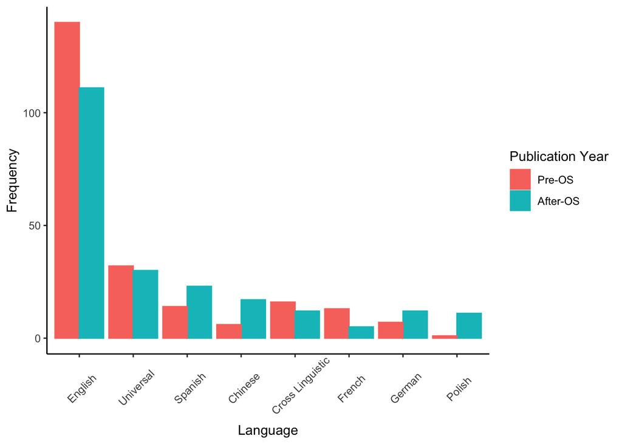

```r
ggplot(lang_summary, aes(language, frequency,
                         color = year_split, fill = year_split)) +
  geom_bar(stat = "identity", position = position_dodge()) +
  theme_classic() +
  ylab("Frequency") +
  xlab("Language") +
  theme(axis.text.x = element_text(angle = 45, vjust = 0.5, hjust=0.4)) +
  scale_color_discrete(name = "Publication Year") +
  scale_fill_discrete(name = "Publication Year")
```

```r
# TR enters ;)

# define handy function
'%!in%' <- function(x,y)!('%in%'(x,y))

lang_summary_all <- langDF %>%
  mutate(language_new = ifelse(language %!in% c("english", "universal", "spanish", "chinese", "cross linguistic", "german"),
                           "other", language)) %>%
  group_by(language_new, year_split) %>%
  summarise(frequency = n()) %>%
  ungroup() %>%
  mutate(language_new=factor(tools::toTitleCase(language_new),levels = unique(tools::toTitleCase(language_new)),ordered = T)) %>%
  mutate(year_split = factor(year_split, levels = c("Pre-OS", "After-OS")))
# please someone make this in one pipeline
freq_split <- lang_summary_all %>%
  group_by(year_split) %>%
  summarise(frequency_split = sum(frequency)) %>%
  ungroup() %>%
  full_join(lang_summary_all) %>%
  mutate(prop = round(frequency / frequency_split, 3) * 100) %>%
  group_by(year_split) %>%
  arrange(desc(prop)) %>%
  ungroup()
```

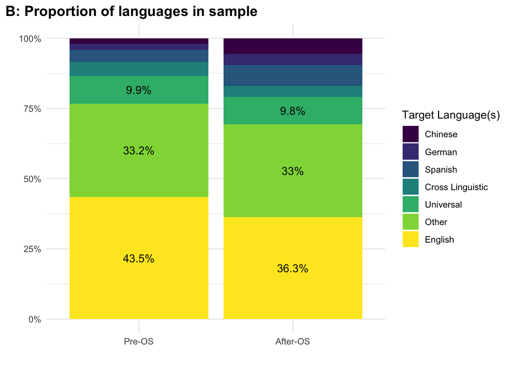

```r
colors_lang = c("#8dd3c7",
                "#ffffb3",
                "#bebada",
                "#fb8072",
                "#80b1d3",
                "#fdb462",
                "#b3de69")

freq_split$language_new <- factor(freq_split$language_new,
                levels = c("Chinese", "German",
                           "Spanish", "Cross Linguistic",
                           "Universal", "Other",
                           "English"))

bar_languages <-
  ggplot(freq_split, aes(x = year_split,
                         y =  prop,
                         fill = language_new)) +
  geom_bar(stat = "identity",
           #col = "black",
           position = position_stack()) +
  geom_text(data = freq_split[freq_split$language_new %in% c("English", "Other", "Universal"),],
            aes(x = year_split,
                y = prop,
                label = paste0(prop, "%")),
            position = position_stack(vjust = 0.5)) +
  labs(title = "B: Proportion of languages in sample",
       x = "",
       y = "") +
  scale_x_discrete(limits = c("Pre-OS","After-OS")) +
  scale_y_continuous(breaks = c(0,25,50,75,100),
                     labels = c("0%", "25%", "50%", "75%", "100%")) +
  guides(fill = guide_legend(title="Target Language(s)")) +
  scale_fill_viridis_d() +
  theme_minimal() +
  theme(
    legend.position = "right",
    plot.title = element_text(face = "bold",
                                       size = 14),
    plot.subtitle = element_text(size = 12),
    plot.title.position = "plot"
  )

bar_languages
```

### JIF

- Journal impact factor at year of publication
  - What is the journal impact factor of the article at the time of publication?.
  - Free text response (numerical)
  - Additional instructions: “To identify journal impact factors use the Thomson Reuters Journal Citation Reports (https://jcr.clarivate.com/). If you have no access to the website, code as”NO ACCESS”, if no JIF is available for year of publication, take first available JIF after year of publication and note the year of JIF in 2.2b below. If no JIF is available at all, code as NA.”
- Year of journal impact factor (if not = year of publication)
  - What is the year of journal impact factor (if not = year of publication)
  - Free text response (numerical)

**Note**: We had a separate group code JIF, as only a few had access to the database with these values.

```r
#JIF <- import("JIF_update.xlsx")
JIF <- import("../analysis/JIF_update.xlsx")
# describe jif
describeBy(as.numeric(JIF$JIF), group = JIF$Year)
```

```
##
##  Descriptive statistics by group
## group: 2008
##    vars   n mean   sd median trimmed  mad  min  max range skew kurtosis   se
## X1    1 139 1.01 0.82    0.8    0.87 0.55 0.04 3.48  3.44 1.62     2.28 0.07
## ------------------------------------------------------------
## group: 2009
##    vars   n mean   sd median trimmed  mad  min  max range skew kurtosis   se
## X1    1 116 1.04 0.78   0.83    0.93 0.62 0.07 3.56   3.5 1.28     1.23 0.07
## ------------------------------------------------------------
## group: 2018
##    vars   n mean   sd median trimmed  mad min  max range skew kurtosis   se
## X1    1 101 1.42 0.81    1.5     1.4 0.68   0 3.76  3.76 0.31    -0.13 0.08
## ------------------------------------------------------------
## group: 2019
##    vars   n mean   sd median trimmed  mad  min  max range skew kurtosis   se
## X1    1 111 1.47 0.95   1.35    1.37 0.85 0.16 5.75  5.58 1.75     5.47 0.09
```

```r
# enter TR
JIF_new <- JIF %>%
  filter(JIFYear != "NA") %>%
  mutate(JIF = as.numeric(JIF),
         JIFYear = as.numeric(JIFYear),
    year_split = ifelse(JIFYear > 2016, "After-OS", "Pre-OS"))

describeBy(as.numeric(JIF_new$JIF), JIF_new$year_split)
```

```
##
##  Descriptive statistics by group
## group: After-OS
##    vars   n mean   sd median trimmed mad min  max range skew kurtosis   se
## X1    1 222 1.44 0.86   1.39    1.37 0.8   0 5.75  5.75 1.34     4.31 0.06
## ------------------------------------------------------------
## group: Pre-OS
##    vars   n mean   sd median trimmed  mad min  max range skew kurtosis   se
## X1    1 236 1.01 0.81    0.8    0.88 0.59   0 3.56  3.56  1.5     1.89 0.05
```

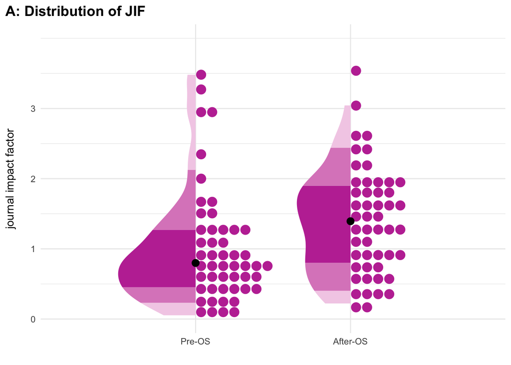

```r
# put to top once integrated
library(ggdist)

JIF_new_agg <- JIF_new %>%
  group_by(year_split) %>%
  summarize(sum = n(),
            se = sd(JIF, na.rm = TRUE) / sqrt(sum),
            JIF = median(JIF, na.rm = TRUE))

JIF_new$year_split <- factor(JIF_new$year_split,
                      levels = c("Pre-OS", "After-OS"))

JIF_plot <-
ggplot(JIF_new,
       aes(x = year_split,
           #y = JIF
           y = JIF
           #colour = year_split
           )) +
    stat_slab(data = JIF_new,
            aes(y = JIF,
                fill_ramp = stat(cut_cdf_qi(cdf,
                                            .width = c(.5, .8, .95),
                                            labels = scales::percent_format()))),
            color = NA,
            fill = "#C038A3",
            scale = 0.5,
            side = "left") +
    scale_fill_ramp_discrete(from = "white",
                           range = c(1,0.25)) +
    stat_dotsinterval(scale = 0.5,
                      fill = "#C038A3",
                    quantiles = 50,
                    side = "right",
                    slab_color = NA,
                    show_point = FALSE,
                    show_interval = FALSE) +
  geom_point(data = JIF_new_agg,
             aes(x = year_split,
                 y = JIF),
             color = "black",
             size = 3) +
  labs(title = "A: Distribution of JIF",
       #subtitle = "for 2008-2009 (left) and 2018-2019 (right)",
       x = "",
       y = "journal impact factor\n") +
  scale_y_continuous(breaks = c(0,1,2,3),
                     limits = c(0,4)) +
  theme_minimal() +
  theme(
    legend.position = "none",
    plot.title = element_text(face = "bold",
                                       size = 14),
    plot.subtitle = element_text(size = 12),
    plot.title.position = "plot"
  )

# DF %>% select(JIF, JIFYear, ArticleID, Source.title, Year) %>%
#   export(x = ., file = "jif_update.csv", row.names = F)

JIF_plot
```

### Country

- Which country is the corresponding author based in according to their affiliation?
  - USA / China / UK / Germany / Japan / France / Canada / Italy / India / Spain / /Unclear /Other *
  - Additional instructions: “For the question about the country, check the institutional affiliation of the corresponding author. If there are multiple corresponding authors, choose the first. If no corresponding author is identified, choose the first. If there are multiple affiliations for the selected author, choose the first.”

```r
# fix up typos
DF$CountryAuthor <- gsub("The Netherands", "The Netherlands", DF$CountryAuthor)
DF$CountryAuthor <- gsub("The Netherlands", "Netherlands", DF$CountryAuthor)
DF$CountryAuthor <- gsub("Hongkong", "Hong Kong", DF$CountryAuthor)

DF$CountryAuthor <- gsub("Finnland", "Finland", DF$CountryAuthor)
DF$CountryAuthor <- gsub("Republic of Ireland", "Ireland", DF$CountryAuthor)
DF$CountryAuthor <- gsub("Republic of South Africa", "South Africa", DF$CountryAuthor)
DF$CountryAuthor <- gsub(", Germany", "", DF$CountryAuthor)
DF$CountryAuthor <- gsub(", Poland", "", DF$CountryAuthor)
DF$CountryAuthor <- gsub("Brasil", "Brazil", DF$CountryAuthor)
DF$CountryAuthor <- gsub("NA", NA, DF$CountryAuthor)
DF$CountryAuthor <- gsub("Unclear", NA, DF$CountryAuthor)


table(DF$CountryAuthor, useNA = "ifany")
```

```
##
##      Australia        Austria        Belgium         Brazil       Cameroon
##             21              2              7              1              1
##         Canada          Chile          China        Croatia         Cyprus
##             17              3             24              1              1
## Czech Republic        Denmark        Estonia           Fiji        Finland
##              2              7              1              1              2
##         France        Germany          Ghana Ghana, Estonia         Greece
##             14             23              1              1              1
##      Hong Kong        Hungary          India           Iran        Ireland
##              4              1              2              5              3
##         Israel          Italy          Japan          Korea         Kuwait
##              3              8             14              1              1
##      Lithuania          Macao       Malaysia         Mexico    Netherlands
##              1              1              6              1             23
##    New Zealand        Nigeria         Norway    Philippines         Poland
##              3              1              7              2             10
##       Portugal         Russia   Saudi Arabia         Serbia      Singapore
##              2              5              2              1              4
##       Slovakia       Slovenia   South Africa    South Korea          Spain
##              2              2              6              2             20
##          Sudan         Sweden    Switzerland         Taiwan       Tanzania
##              1              8              5              5              2
##       Thailand         Turkey             UK            USA          Yemen
##              2              1             48            160              1
##           <NA>
##             70
```

```r
DF$CountryCode <- countrycode(sourcevar = DF$CountryAuthor,
                              origin = 'country.name',
                              destination = 'iso2c')
```

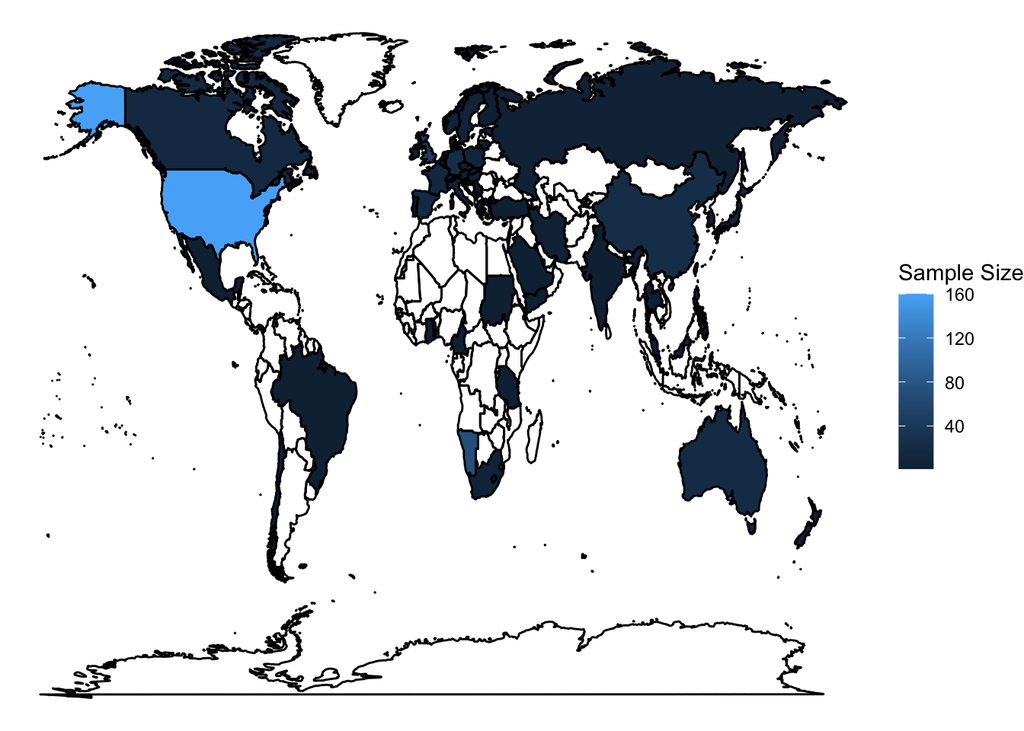

```r
world_map <- map_data(map = "world")
world_map$region <- iso.alpha(world_map$region)

country_summary <- DF %>%
      group_by(CountryCode) %>%
      summarize(n = n())

country_summary$Region <- countrycode(
  sourcevar = country_summary$CountryCode,
  origin = 'iso2c',
  destination = "un.regionsub.name")
country_summary$Region[country_summary$CountryCode == "TW"] <- "Eastern Asia"

ggplot(country_summary) +
  geom_map(aes(map_id = CountryCode, fill = n), map = world_map) +
  geom_polygon(data = world_map, aes(x = long, y = lat, group = group), colour = 'black', fill = NA) +
  theme_void() +
  scale_fill_continuous(name = "Sample Size")
```

```r
# TR enters ;) UK, USA, Australia, Germany, China, Netherlands, Spain

country_summary_new <- DF %>%
   mutate(CountryAuthor_new = ifelse(CountryAuthor %!in% c("UK", "USA", "Australia", "Germany", "China", "Netherlands", "Spain"), "Other", CountryAuthor)) %>%
      group_by(CountryAuthor_new, year_split) %>%
      summarize(frequency = n()) %>%
      ungroup()
country_split <- country_summary_new %>%
  group_by(year_split) %>%
  summarise(frequency_split = sum(frequency)) %>%
  full_join(country_summary_new) %>%
  mutate(prop = round(frequency / frequency_split, 3) * 100)
```

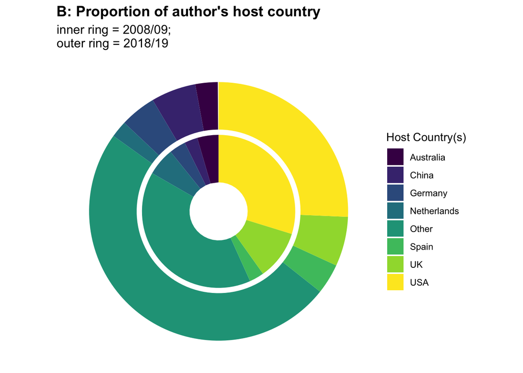

```r
donut_countries <- ggplot(country_split, aes(x = year_split, y = prop, fill = CountryAuthor_new)) +
  geom_col() +
  coord_polar("y") +
  labs(title = "B: Proportion of author's host country",
       subtitle = "inner ring = 2008/09; \nouter ring = 2018/19") +
  scale_x_discrete(limits = c(" ", "Pre-OS","After-OS")) +
  guides(fill = guide_legend(title="Host Country(s)")) +
  theme_void() +
  scale_fill_viridis_d() +
  theme(
    plot.title = element_text(face = "bold",
                                       size = 14),
    plot.subtitle = element_text(size = 12),
    plot.title.position = "plot"
  )


# Put JIF and country plot together
sample_characteristics <- JIF_plot  + bar_languages + plot_layout(widths = c(1, 0.7))

ggsave(filename = "../plots/sample_characteristics.png",
       plot = sample_characteristics,
       device = "png",
       width = 177.8,
       height = 100,
       units = "mm",
       dpi = 500)
donut_countries
```

```r
country_summary2 <- DF %>%
      group_by(CountryCode, year_split) %>%
      summarize(n = n())
country_summary2$Region <- countrycode(
  sourcevar = country_summary2$CountryCode,
  origin = 'iso2c',
  destination = "un.regionsub.name")
```

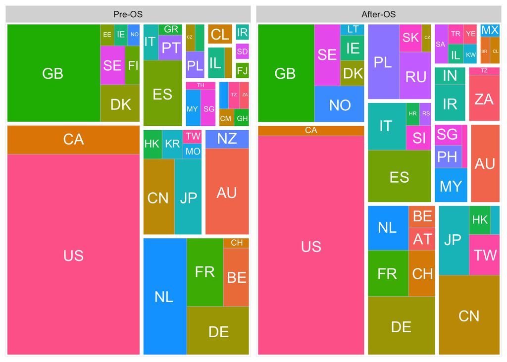

```r
country_summary2$Region[country_summary2$CountryCode == "TW"] <- "Eastern Asia"

country_summary2$year_split <- factor(
  country_summary2$year_split,
  levels = c("Pre-OS", "After-OS"))

library(treemapify)
ggplot(country_summary2 %>% filter(!is.na(Region)),
       aes(area = n, fill = CountryCode,
               label = CountryCode, subgroup = Region)) +
  geom_treemap() +
  geom_treemap_subgroup_border(colour = "white", size = 5) +
  geom_treemap_text(colour = "white", place = "center",
                    size = 15, grow = FALSE) +
  facet_wrap(~year_split) +
  theme(legend.position = "none")
```

### Study type/design

- What type of study is being reported?
  - Multiple choice (see Table 2 for response options).
  - Additional instructions: “Mark only one oval. Examine the title, abstract, and if necessary the methods section, to establish the study characteristics.”

```r
DF$StudyType[grepl("^No empirical data", DF$StudyType)] <- "No empirical data"
table(DF$StudyType, useNA = "ifany")
```

```
##
##                          Data synthesis - Meta-analysis.
##                                                        4
## Empirical data (specify the study type in the next step)
##                                                      362
##                                        No empirical data
##                                                      152
##                                                     <NA>
##                                                       59
```

```r
table(DF$StudyType, DF$year_split, useNA = "ifany")
```

```
##
##                                                            After-OS Pre-OS
##   Data synthesis - Meta-analysis.                                 2      2
##   Empirical data (specify the study type in the next step)      187    175
##   No empirical data                                              65     87
##   <NA>                                                           34     25
```

### Type of empirical study

- If the article reports empirical data, what type of empirical data study is being reported?
  - Experimental study /
  - Corpus study /
  - Field study or language description /
  - Survey or interview /
  - Typological study /
  - Multiple study type reported /
  - Other

```r
DF$EmpiricalStudyData <- sub(" with no systematically sampled material, just selected examples ", "", DF$EmpiricalStudyData)
DF$EmpiricalStudyData <- sub(", Not language per se but report about reading experiences was analysed qualitatively", "", DF$EmpiricalStudyData)
DF$EmpiricalStudyData <- sub("(only 6 patients, all tested on battery of tasks)", "", DF$EmpiricalStudyData)
DF$EmpiricalStudyData <- sub("^na$", NA, DF$EmpiricalStudyData)
DF$EmpiricalStudyData <- trimws(tolower(DF$EmpiricalStudyData))

studyDF <- DF %>%
  select(EmpiricalStudyData, year_split, ArticleID) %>%
  separate(EmpiricalStudyData, sep = ",", into = c("A", "B", "C"),
           extra = "warn") %>%
  pivot_longer(cols = c(A,B,C)) %>%
  filter(!is.na(value)) %>%
  select(year_split, value, ArticleID) %>%
  rename(study = value) %>%
  filter(study != "")
studyDF$study <- sub("case studies", "case study", studyDF$study)
studyDF$study <- sub("could be also considered collection of case study.*", "case study", studyDF$study)
studyDF$study <- sub(" with no systematically sampled material", "", studyDF$study)
studyDF$study <- sub("partly also ", "", studyDF$study)
studyDF$study <- gsub("observation.*", "observation", studyDF$study)
studyDF$study <- gsub("intervention.*", "observation", studyDF$study)
studyDF$study <- gsub(".*modelling.*", "modelling", studyDF$study)
studyDF$study <- sub("interviews", "survey or interview", studyDF$study)
studyDF$study <- sub("description of archive of stuttered speech", "corpus study", studyDF$study)
studyDF$study <- gsub("correlational study|formal phonology|introspection|just selected examples|case study|meta analysis|modelling|^na$|secondary data from previous reports|simulation|test battery on language   cognitive skills", "other", studyDF$study)

# these damned "spaces" what a dumb hack
studyDF$study <- gsub("[^[:alnum:]]", "9", studyDF$study)
studyDF$study <- gsub("^9+(.+)", "\\1", studyDF$study)
studyDF$study <- gsub("(.+)9+$", "\\1", studyDF$study)
studyDF$study <- gsub("9", " ", studyDF$study)

table(studyDF$study, useNA = "ifany")
```

```
##
##                                corpus study
##                                          92
##                          discourse analysis
##                                          12
##                          experimental study
##                                         120
##         field study or language description
##                                          11
##                               meta analysis
##                                           1
##               multiple study types reported
##                                           2
##                                 observation
##                                          83
##                                       other
##                                          17
##                         survey or interview
##                                          65
## test battery on language   cognitive skills
##                                           1
##                           typological study
##                                           9
```

```r
table(studyDF$study, studyDF$year_split, useNA = "ifany")
```

```
##
##                                               After-OS Pre-OS
##   corpus study                                      46     46
##   discourse analysis                                 6      6
##   experimental study                                59     61
##   field study or language description                4      7
##   meta analysis                                      1      0
##   multiple study types reported                      0      2
##   observation                                       45     38
##   other                                              7     10
##   survey or interview                               40     25
##   test battery on language   cognitive skills        0      1
##   typological study                                  4      5
```

```r
study_summary <- studyDF %>%
  group_by(study, year_split) %>% summarise(frequency=n()) %>%
  ungroup() %>%
  arrange(desc(frequency)) %>%
  mutate(study=factor(tools::toTitleCase(study),levels = unique(tools::toTitleCase(study)),ordered = T)) %>%
  filter(frequency >= 8) %>%
  mutate(year_split = factor(year_split, levels = c("Pre-OS", "After-OS")))
```

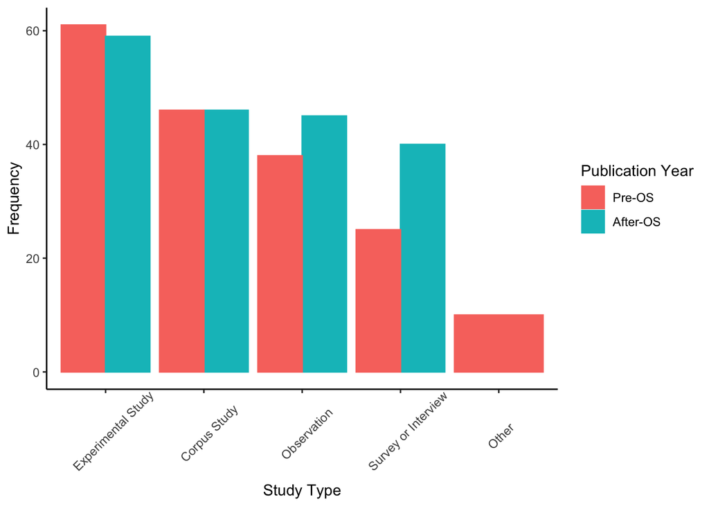

```r
ggplot(study_summary, aes(study, frequency,
                         color = year_split, fill = year_split)) +
  geom_bar(stat = "identity", position = position_dodge()) +
  theme_classic() +
  ylab("Frequency") +
  xlab("Study Type") +
  theme(axis.text.x = element_text(angle = 45, vjust = 0.5, hjust=0.4)) +
  scale_color_discrete(name = "Publication Year") +
  scale_fill_discrete(name = "Publication Year")
```

## Preregistration

- Definitions: “Preregistration” refers to the timestamped registration of important aspects of the study (typically hypotheses, methods, and/or analysis plan) prior to commencement of the study.
- Coder instructions: Check specific sections where these files might be located e.g., supplementary materials, appendices, author notes, methods, and results sections. Search for “*registration” or ”*registered”.

### Preregistration

- Does the article state whether or not the study (or some aspect of the study) was preregistered?
  - Yes – there is a preregistration/
  - No – there is no preregistration/
  - Other*

```r
table(DF$PreReg)
```

```
##
##                   No, there is no preregistration.
##                                                  3
## No, there is no preregistration. (GO TO SECTION 4)
##                                                359
```

### Preregistration method

- Where does the article indicate the preregistration is located?
  - Open Science Framework (osf.io) /
  - AsPredicted (aspredicted.org) /
  - Registered Report /
  - Other*

```r
table(DF$PreRegWhere)
```

```
## < table of extent 0 >
```

### Preregistration accessible

- Can you access and open the preregistration?
  - Yes / No / Other*

```r
table(DF$PreRegAccess)
```

```
## < table of extent 0 >
```

### Preregistration content

- What aspects of the study appear to be preregistered? (select all that apply)
  - Hypotheses /
  - Data collection /
  - Analysis /
  - Other*

```r
table(DF$PreRegAspects)
```

```
## < table of extent 0 >
```

## Data sharing

- Definitions: “data” refers to recorded information that supports the analyses reported in the article. For our purposes, we differentiate between different types of data. “Raw data” refers to the recorded information in its rawest, digital form, at the level of sampling units (e.g., participants, words, utterances, trials, etc). “Processed data” refers to a derived form of the data that has undergone changes from its raw state (e.g., extraction of acoustic parameters via Praat, aggregates of responses, etc.).
- A “data availability statement” can be as simple as a url link to a data file, or as complex as a written explanation as to why data cannot be shared.
- Coder instructions: Check the article for a data availability statement/link. They are often located in the “supplementary material”, “acknowledgements”, “author notes”, “methods”, or “results” sections. Search the article for the text “data availab*” (to cover “data availability” and “data available”). Search for links using “www” or “http”.

### Raw data type

- What is the nature of the raw data files?
  - Not applicable /
  - Text file /
  - Audio /
  - Video /
  - Images /
  - Other

```r
DF$RawData <- sub("Individual examples of linguistic phenomenon >> text files\\?", "Text file", DF$RawData)
DF$RawData <- sub("Not applicable, Examples of analyzed sentences provided in article text", "Not applicable", DF$RawData)
DF$RawData <- sub("Not applicable, Examples of sentences in text \\(syntactic analysis\\)", "Not applicable", DF$RawData)
DF$RawData <- sub('survey results: choices of single vowels >> counts as "text"\\?', "Text file", DF$RawData)
DF$RawData <- sub("single examples", "Text file", DF$RawData)
DF$RawData <- sub(", Answers obtained from stimuli items", "", DF$RawData)
DF$RawData <- sub(", Survey responses", "", DF$RawData)
DF$RawData <- sub(", individual examples in article >> text files\\?", "", DF$RawData)
DF$RawData <- sub(', results of experiment with reaction times >> counts as "text"\\?', "", DF$RawData)
DF$RawData <- sub(", online corpus", "", DF$RawData)
DF$RawData <- sub("Unclear", NA, DF$RawData)
DF$RawData <- sub("Not applicable", NA, DF$RawData)

table(DF$RawData, useNA = "ifany")
```

```
##
##                   Audio            Audio, Video                  Images
##                      42                       5                       1
##               Text file        Text file, Audio Text file, Audio, Video
##                     226                      41                       7
##       Text file, Images        Text file, Video                   Video
##                       6                      13                      14
##                    <NA>
##                     222
```

```r
dataDF <- DF %>%
  select(RawData, year_split, ArticleID) %>%
  separate(RawData, sep = ",", into = c("A", "B", "C"),
           extra = "warn") %>%
  pivot_longer(cols = c(A,B, C)) %>%
  filter(!is.na(value)) %>%
  select(year_split, value, ArticleID) %>%
  rename(data = value) %>%
  filter(data != "")
dataDF$data <- gsub("[^[:alnum:]]", "9", dataDF$data)
dataDF$data <- gsub("^9+(.+)", "\\1", dataDF$data)
dataDF$data <- gsub("(.+)9+$", "\\1", dataDF$data)
dataDF$data <- gsub("9", " ", dataDF$data)

data_summary <- dataDF %>%
  group_by(data, year_split) %>% summarise(frequency=n()) %>%
  ungroup() %>%
  arrange(desc(frequency)) %>%
  mutate(data=factor(tools::toTitleCase(data),levels = unique(tools::toTitleCase(data)),ordered = T)) %>%
  filter(frequency >= 8) %>%
  mutate(year_split = factor(year_split, levels = c("Pre-OS", "After-OS")))
```

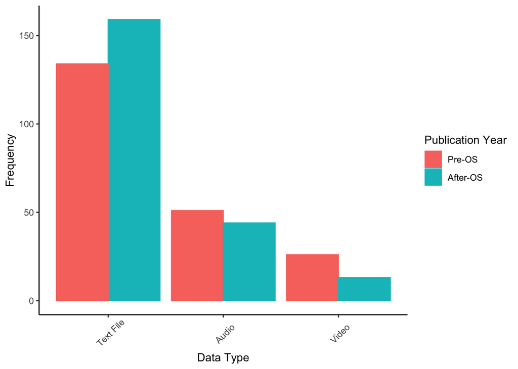

```r
ggplot(data_summary, aes(data, frequency,
                         color = year_split, fill = year_split)) +
  geom_bar(stat = "identity", position = position_dodge()) +
  theme_classic() +
  ylab("Frequency") +
  xlab("Data Type") +
  theme(axis.text.x = element_text(angle = 45, vjust = 0.5, hjust=0.4)) +
  scale_color_discrete(name = "Publication Year") +
  scale_fill_discrete(name = "Publication Year")
```

### Raw data statement

- Does the article state whether or not raw data are available?
  - Yes, the statement says that the raw data are available /
  - No - raw data are not available.(GO TO SECTION 4.6) /
  - Other*

```r
DF$RawDataAvl <- sub(".*corp.*", "Yes - Corpus", DF$RawDataAvl)
DF$RawDataAvl <- sub("No statement but links to data sources|Raw data \\(examples\\) are provided within the publication", "Yes, the statement says that the raw data are available.", DF$RawDataAvl)
DF$RawDataAvl <- sub(".*third.*", "Yes - Third Party", DF$RawDataAvl)
DF$RawDataAvl <- sub("State that the data is no longer available", "No, raw data are not available.  (GO TO SECTION 4.6)", DF$RawDataAvl)
DF$RawDataAvl <- sub("Some raw data available", "Yes, the statement says that the raw data are available.", DF$RawDataAvl)
DF$RawDataAvl <- sub("No, raw data are not available. \\(GO TO SECTION 4.6\\)",
                     "No, raw data are not available.  \\(GO TO SECTION 4.6\\)",
                     DF$RawDataAvl)

table(DF$RawDataAvl, useNA = "ifany")
```

```
##
##                                                  Corpus cited, other data not available
##                                                                                       1
##                                    No, raw data are not available.  (GO TO SECTION 4.6)
##                                                                                     310
## No, raw data are not available. (authors say dataset will be available upon completion)
##                                                                                       1
##                                                                            Yes - Corpus
##                                                                                      10
##                                                                       Yes - Third Party
##                                                                                       2
##                                Yes, the statement says that the raw data are available.
##                                                                                      38
##                                                                                    <NA>
##                                                                                     215
```

```r
table(DF$RawDataAvl, DF$year_split, useNA = "ifany")
```

```
##
##                                                                                           After-OS
##   Corpus cited, other data not available                                                         1
##   No, raw data are not available.  (GO TO SECTION 4.6)                                         160
##   No, raw data are not available. (authors say dataset will be available upon completion)        1
##   Yes - Corpus                                                                                   7
##   Yes - Third Party                                                                              0
##   Yes, the statement says that the raw data are available.                                      18
##   <NA>                                                                                         101
##
##                                                                                           Pre-OS
##   Corpus cited, other data not available                                                       0
##   No, raw data are not available.  (GO TO SECTION 4.6)                                       150
##   No, raw data are not available. (authors say dataset will be available upon completion)      0
##   Yes - Corpus                                                                                 3
##   Yes - Third Party                                                                            2
##   Yes, the statement says that the raw data are available.                                    20
##   <NA>                                                                                       114
```

### Raw data sharing method

- How does the statement indicate that the raw data are available?
  - Upon request from the authors /
  - Personal or institution website /
  - An online, third-party repository (e.g., OSF, GitHub, FigShare etc.) /
  - Supplementary materials hosted by the journal /
  - Available from a third party /
  - Unclear /
  - Other*

```r
DF$RawDataWhere <- sub("as part of the article \\(individual examples\\)|raw data are available as individual examples in the article", "In Article", DF$RawDataWhere)
DF$RawDataWhere <- sub("Blog", "Personal or institutional website", DF$RawDataWhere)
DF$RawDataWhere <- sub(".*corpus.*", "Available from a third party", DF$RawDataWhere)
DF$RawDataWhere <- sub("Links to online sources, one does not work", "Available from a third party", DF$RawDataWhere)
DF$RawDataWhere <- sub("^NA$", NA, DF$RawDataWhere)

table(DF$RawDataWhere, useNA = "ifany")
```

```
##
## An online, third-party repository (e.g. OSF, GitHub, FigShare, etc.)
##                                                                    3
##                                         Available from a third party
##                                                                   36
##                               Corpus cited, other data not available
##                                                                    1
##                                                           In Article
##                                                                    2
##                                    Personal or institutional website
##                                                                    2
##                       State that website used is no longer available
##                                                                    1
##                        Supplementary materials hosted by the journal
##                                                                    2
##                                                              Unclear
##                                                                    3
##                                        Upon request from the authors
##                                                                    1
##                                                                 <NA>
##                                                                  526
```

```r
table(DF$RawDataWhere, DF$year_split, useNA = "ifany")
```

```
##
##                                                                        After-OS
##   An online, third-party repository (e.g. OSF, GitHub, FigShare, etc.)        3
##   Available from a third party                                               17
##   Corpus cited, other data not available                                      1
##   In Article                                                                  0
##   Personal or institutional website                                           1
##   State that website used is no longer available                              1
##   Supplementary materials hosted by the journal                               2
##   Unclear                                                                     2
##   Upon request from the authors                                               0
##   <NA>                                                                      261
##
##                                                                        Pre-OS
##   An online, third-party repository (e.g. OSF, GitHub, FigShare, etc.)      0
##   Available from a third party                                             19
##   Corpus cited, other data not available                                    0
##   In Article                                                                2
##   Personal or institutional website                                         1
##   State that website used is no longer available                            0
##   Supplementary materials hosted by the journal                             0
##   Unclear                                                                   1
##   Upon request from the authors                                             1
##   <NA>                                                                    265
```

### Raw data accessibility

- Can you access, download, and open the raw data files without an additional step such as a sign-up or a login?
  - Yes / No / Other*

```r
table(DF$RawDataAccess, useNA = "ifany")
```

```
##
##                                                Can't find
##                                                         1
##                                       Corpus is available
##                                                         1
## Link to the corpus provided but not to the exact raw data
##                                                         1
##                                                        NA
##                                                         1
##                                                        No
##                                                        32
##                         No, Corpus can be accessed freely
##                                                         1
##                            Not all websites provided work
##                                                         1
##           Unable to locate from info available in article
##                                                         1
##                                                       Yes
##                                                        14
##                                                      <NA>
##                                                       524
```

```r
table(DF$RawDataAccess, DF$year_split, useNA = "ifany")
```

```
##
##                                                             After-OS Pre-OS
##   Can't find                                                       1      0
##   Corpus is available                                              1      0
##   Link to the corpus provided but not to the exact raw data        1      0
##   NA                                                               1      0
##   No                                                              14     18
##   No, Corpus can be accessed freely                                1      0
##   Not all websites provided work                                   0      1
##   Unable to locate from info available in article                  1      0
##   Yes                                                              8      6
##   <NA>                                                           260    264
```

### Raw data documentation

- Are the raw data files documented, i.e., are there meta-data that state the nature and content of individual files? For text files, is there a data dictionary / “code book” that describes the nature of individual variables?
  - Yes / No / Unclear / Other*

```r
table(DF$RawDataDocument, useNA = "ifany")
```

```
##
##      NA      No Unclear     Yes    <NA>
##       2      15      30       7     523
```

```r
table(DF$RawDataDocument, DF$year_split, useNA = "ifany")
```

```
##
##           After-OS Pre-OS
##   NA             1      1
##   No             8      7
##   Unclear       15     15
##   Yes            4      3
##   <NA>         260    263
```

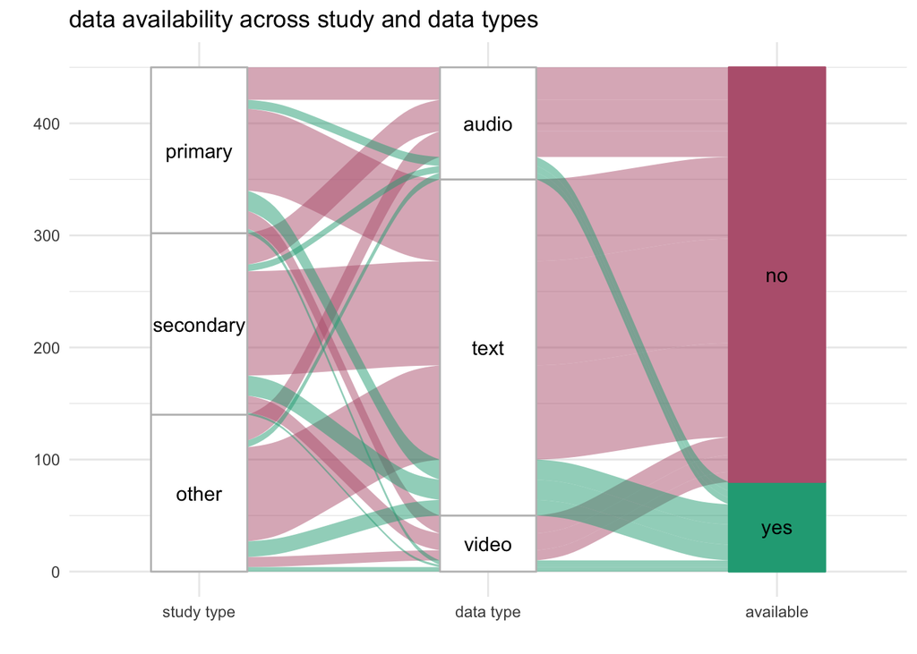

```r
# first river plot attempts
# remotes::install_github("corybrunson/ggalluvial", ref = "optimization")
library(ggalluvial)
library(ggfittext)

# make fake data, wrangle real data later
dummy_df <- data.frame(study_type = sample(c("primary", "secondary", "other"), 450, replace = TRUE),
                       data_type = c(rep("text", 300), rep("audio", 100), rep("video", 50)),
                       available = c(rep("yes", 50), rep("no", 250),
                                     rep("yes", 20), rep("no", 80),
                                     rep("yes", 10), rep("no", 40))) %>%
  mutate(study_type = factor(study_type, levels = c("primary", "secondary", "other"))) %>%
  group_by(study_type, data_type, available) %>%
  summarize(sum = n())
ggplot(data = dummy_df,
       aes(axis1 = study_type,
           axis2 = data_type,
           axis3 = available,
           fill = available,
           y = sum)) +
  scale_x_discrete(limits = c("study type", "data type", "available"), expand = c(.2, .05)) +
  scale_fill_manual(values = c("#b8627dff", "#22A884FF")) +
  labs(title = "data availability across study and data types",
       y = "",
       x = "") +
  geom_alluvium() +
  geom_stratum(color = c("grey", "grey", "grey",
                        "grey", "grey", "grey",
                        "#22A884FF", "#b8627dff"),
               fill = c("white", "white", "white",
                        "white", "white", "white",
                        "#22A884FF", "#b8627dff")) +
  #ggfittext::geom_fit_text(stat = "stratum", width = 1/4, min.size = 3) +
  geom_text(stat = "stratum", aes(label = after_stat(stratum))) +
  theme_minimal() +
  theme(legend.position =  "none",
        )
```

### Processed data statement

- Does the article state whether or not processed data are available?
  - Yes, the statement says that the processed data are available /
  - No, processed data are not available. /
  - Other*

```r
DF$ProcessData <- sub(" \\(GO TO SECTION 5\\)", "", DF$ProcessData)

table(DF$ProcessData, useNA = "ifany")
```

```
##
##                                                         No, processed data are not available.
##                                                                                           334
## No, processed data are not available. (authors say dataset will be available upon completion)
##                                                                                             1
##                       Points to third-party data sources, unclear what kind of data available
##                                                                                             1
##                                                                     raw data = processed data
##                                                                                             1
##                                 Yes, the statement says that the processed data are available
##                                                                                            12
##                                                                                          <NA>
##                                                                                           228
```

```r
table(DF$ProcessData, DF$year_split, useNA = "ifany")
```

```
##
##                                                                                                 After-OS
##   No, processed data are not available.                                                              176
##   No, processed data are not available. (authors say dataset will be available upon completion)        1
##   Points to third-party data sources, unclear what kind of data available                              0
##   raw data = processed data                                                                            0
##   Yes, the statement says that the processed data are available                                       10
##   <NA>                                                                                               101
##
##                                                                                                 Pre-OS
##   No, processed data are not available.                                                            158
##   No, processed data are not available. (authors say dataset will be available upon completion)      0
##   Points to third-party data sources, unclear what kind of data available                            1
##   raw data = processed data                                                                          1
##   Yes, the statement says that the processed data are available                                      2
##   <NA>                                                                                             127
```

### Processed data sharing method

- How does the statement indicate that the processed data are available?
  - Upon request from the authors /
  - Personal or institution website /
  - An online, third-party repository (e.g., OSF, GitHub, FigShare etc.) /
  - Supplementary materials hosted by the journal /
  - Available from a third party /
  - Unclear /
  - Other*

```r
table(DF$ProcessDataWhere, useNA = "ifany")
```

```
##
## An online, third-party repository (e.g. OSF, GitHub, FigShare, etc.)
##                                                                    2
##                                         Available from a third party
##                                                                    3
##                       Link to labeled data provided but doesn't work
##                                                                    1
##                                                                   NA
##                                                                    2
##                                    Personal or institutional website
##                                                                    1
##                        Supplementary materials hosted by the journal
##                                                                    5
##                                        Upon request from the authors
##                                                                    2
##                                                                 <NA>
##                                                                  561
```

```r
table(DF$ProcessDataWhere, DF$year_split, useNA = "ifany")
```

```
##
##                                                                        After-OS
##   An online, third-party repository (e.g. OSF, GitHub, FigShare, etc.)        2
##   Available from a third party                                                1
##   Link to labeled data provided but doesn't work                              1
##   NA                                                                          1
##   Personal or institutional website                                           1
##   Supplementary materials hosted by the journal                               5
##   Upon request from the authors                                               1
##   <NA>                                                                      276
##
##                                                                        Pre-OS
##   An online, third-party repository (e.g. OSF, GitHub, FigShare, etc.)      0
##   Available from a third party                                              2
##   Link to labeled data provided but doesn't work                            0
##   NA                                                                        1
##   Personal or institutional website                                         0
##   Supplementary materials hosted by the journal                             0
##   Upon request from the authors                                             1
##   <NA>                                                                    285
```

### Processed data accessibility

- Can you access, download, and open the processed data files without an additional step such as a sign-up or a login?
  - Yes / No / Other*

```r
table(DF$ProcessDataAccess, useNA = "ifany")
```

```
##
##   NA   No  Yes <NA>
##    2    7    6  562
```

```r
table(DF$ProcessDataAccess, DF$year_split, useNA = "ifany")
```

```
##
##        After-OS Pre-OS
##   NA          1      1
##   No          4      3
##   Yes         6      0
##   <NA>      277    285
```

### Processed data documentation

- Are the processed data files documented, i.e., are there meta-data that state the nature and content of individual files? Is there a data dictionary / “code book” that describes the nature of individual variables?
  - Yes / No / Unclear / Other*

```r
table(DF$ProcessDataDocument, useNA = "ifany")
```

```
##
##                                                     NA
##                                                      2
##                                                     No
##                                                      3
## The author states a codebook is available upon request
##                                                      1
##                                                Unclear
##                                                      5
##                                                    Yes
##                                                      4
##                                                   <NA>
##                                                    562
```

```r
table(DF$ProcessDataDocument, DF$year_split, useNA = "ifany")
```

```
##
##                                                          After-OS Pre-OS
##   NA                                                            1      1
##   No                                                            3      0
##   The author states a codebook is available upon request        1      0
##   Unclear                                                       2      3
##   Yes                                                           4      0
##   <NA>                                                        277    285
```

## Analysis script sharing

Definition: “Analysis scripts” refers to specification of data preparation and analysis steps in the form of highly detailed step-by-step instructions for using point-and-click software (e.g., SPSS), analysis code (e.g., R), or syntax (e.g., from SPSS). - Coder instructions: Check the article for an analysis script availability statement/link. They are often located in the “supplementary material”, “acknowledgements”, “author notes”, “methods”, or “results” sections. Search for the text “analysis script” and “analysis code”. Search for links using “www” or “http”.

### Analysis script availability

- Are analysis scripts available?
  - Yes, analysis scripts are freely available /
  - Authors point to a third party /
  - No, analysis scripts are not available /
  - Other*

```r
DF$AnalysisScript <- sub(" \\(GO TO SECTION 6\\)", "", DF$AnalysisScript)
DF$AnalysisScript <- sub(".*Not applicable.*|The study did not necessitate an analysis script", "Not Applicable", DF$AnalysisScript)

table(DF$AnalysisScript, useNA = "ifany")
```

```
##
## Analysis cannot be made available as the paper applies a qualitative analysis of the data
##                                                                                         1
##                           Link to code on github provided but github page empty (no code)
##                                                                                         1
##                                                   No, analysis scripts are not available.
##                                                                                       348
##                                                                            Not Applicable
##                                                                                        11
##                                                Yes, analysis scripts are freely available
##                                                                                         5
##                                                                                      <NA>
##                                                                                       211
```

```r
table(DF$AnalysisScript, DF$year_split, useNA = "ifany")
```

```
##
##                                                                                             After-OS
##   Analysis cannot be made available as the paper applies a qualitative analysis of the data        0
##   Link to code on github provided but github page empty (no code)                                  1
##   No, analysis scripts are not available.                                                        180
##   Not Applicable                                                                                   3
##   Yes, analysis scripts are freely available                                                       5
##   <NA>                                                                                            99
##
##                                                                                             Pre-OS
##   Analysis cannot be made available as the paper applies a qualitative analysis of the data      1
##   Link to code on github provided but github page empty (no code)                                0
##   No, analysis scripts are not available.                                                      168
##   Not Applicable                                                                                 8
##   Yes, analysis scripts are freely available                                                     0
##   <NA>                                                                                         112
```

### Analysis script sharing method

- How are the analysis scripts accessible?
  - Upon request from the authors /
  - Personal or institution website /
  - An online, third-party repository (e.g., OSF, GitHub, FigShare etc.) /
  - Supplementary materials hosted by the journal /
  - Available from a third party /
  - Unclear /
  - Other*

```r
table(DF$AnalysisScriptWhere, useNA = "ifany")
```

```
##
## An online, third-party repository (e.g. OSF, GitHub, FigShare, etc.)
##                                                                    2
##                      Code used to search corpus is available in text
##                                                                    1
##      Link to code on github provided but github page empty (no code)
##                                                                    1
##                                                                   NA
##                                                                    2
##                        Supplementary materials hosted by the journal
##                                                                    2
##                                                                 <NA>
##                                                                  569
```

```r
table(DF$AnalysisScriptWhere, DF$year_split, useNA = "ifany")
```

```
##
##                                                                        After-OS
##   An online, third-party repository (e.g. OSF, GitHub, FigShare, etc.)        2
##   Code used to search corpus is available in text                             1
##   Link to code on github provided but github page empty (no code)             1
##   NA                                                                          0
##   Supplementary materials hosted by the journal                               2
##   <NA>                                                                      282
##
##                                                                        Pre-OS
##   An online, third-party repository (e.g. OSF, GitHub, FigShare, etc.)      0
##   Code used to search corpus is available in text                           0
##   Link to code on github provided but github page empty (no code)           0
##   NA                                                                        2
##   Supplementary materials hosted by the journal                             0
##   <NA>                                                                    287
```

### Analysis script accessibility

- Can you access, download, and open the analysis scripts without an additional step such as a sign-up or a login?
  - Yes / No / Other*

```r
table(DF$AnalysisScriptAccess, useNA = "ifany")
```

```
##
##          NA          No Unnecessary         Yes        <NA>
##           1           3           1           3         569
```

```r
table(DF$AnalysisScriptAccess, DF$year_split, useNA = "ifany")
```

```
##
##               After-OS Pre-OS
##   NA                 0      1
##   No                 2      1
##   Unnecessary        1      0
##   Yes                3      0
##   <NA>             282    287
```

## Materials / Methods sharing

- Definitions: “materials / methods” refers to any study items that would be needed to repeat the study, such as stimuli, survey instruments, and computer code/software used for data collection, presentation stimuli or running experiments (not including analysis scripts, see next section), study protocols, etc. For present purposes we do not consider supplementary data/findings (e.g., additional figures or tables) to be ‘materials’.
- Coder instructions: Check the article for a materials / methods availability statement/link. They are often located in the “supplementary material”, “acknowledgements”, “author notes”, “methods”, or “results” sections. Search for links using “www” or “http”.

### Materials availability

- Are materials or additional information about the method available?
  - Yes, materials or additional information about the method are freely available /
  - Materials or additional information available through a third party /
  - No, materials or additional information about the method are not available /
  - Other*

```r
DF$Materials <- sub(".*dead.*", "Dead Links", DF$Materials)
DF$Materials <- sub(" \\(GO TO SECTION 7\\)", "", DF$Materials)
DF$Materials <- sub(".*Not applicable.*", "Not Applicable", DF$Materials)
DF$Materials <- sub(".*Supplementary.*|.*Append.*|.*append.*", "Appendix", DF$Materials)
DF$Materials <- sub(".*third.*|Links to online corpora provided", "Third Party", DF$Materials)

table(DF$Materials, useNA = "ifany")
```

```
##
##                                                                       Appendix
##                                                                             10
##                                                                     Dead Links
##                                                                              2
##    No, materials or additional information about the method are not available.
##                                                                            305
##                                                                 Not Applicable
##                                                                              3
##                                                                    Third Party
##                                                                             26
## Yes, materials or additional information about the method are freely available
##                                                                             20
##                                                                           <NA>
##                                                                            211
```

```r
table(DF$Materials, DF$year_split, useNA = "ifany")
```

```
##
##                                                                                  After-OS
##   Appendix                                                                              6
##   Dead Links                                                                            0
##   No, materials or additional information about the method are not available.         151
##   Not Applicable                                                                        0
##   Third Party                                                                          16
##   Yes, materials or additional information about the method are freely available       16
##   <NA>                                                                                 99
##
##                                                                                  Pre-OS
##   Appendix                                                                            4
##   Dead Links                                                                          2
##   No, materials or additional information about the method are not available.       154
##   Not Applicable                                                                      3
##   Third Party                                                                        10
##   Yes, materials or additional information about the method are freely available      4
##   <NA>                                                                              112
```

### Materials sharing method

- How are the materials or additional information about the method accessible?
  - Upon request from the authors /
  - Personal or institution website /
  - An online, third-party repository (e.g., OSF, GitHub, FigShare etc.) /
  - Supplementary materials hosted by the journal /
  - Available from a third party /
  - Unclear /
  - Other*
- Additional instructions: “If authors point to a third party via a reference only, mark”Available from a third party”.”

```r
DF$MaterialsWhere <- sub(".*append.*|.*Suppl.*|.*Append.*|In the actual article", "Appendix", DF$MaterialsWhere)
DF$MaterialsWhere <- sub(".*brok.*|.*dead.*", "Dead Links", DF$MaterialsWhere)
DF$MaterialsWhere <- sub(".*some materials.*", "Some materials shared", DF$MaterialsWhere)
DF$MaterialsWhere <- sub(".*Some materials.*|.*Some avail.*", "Some materials shared", DF$MaterialsWhere)

table(DF$MaterialsWhere, useNA = "ifany")
```

```
##
##              An online, third-party repository (e.g. OSF, GitHub, FigShare, etc.)
##                                                                                 2
##                                                                          Appendix
##                                                                                25
## Authors state materials are available in a separate article that is under paywall
##                                                                                 1
##                                                      Available from a third party
##                                                                                11
##                                                 Dead link to the test application
##                                                                                 1
##                                                                        Dead Links
##                                                                                 3
##                                                              link to porn website
##                                                                                 1
##                                                                                NA
##                                                                                 2
##                                                 Personal or institutional website
##                                                                                 3
##                                                             Some materials shared
##                                                                                 9
##                                                     Upon request from the authors
##                                                                                 3
##                                                                              <NA>
##                                                                               516
```

```r
table(DF$MaterialsWhere, DF$year_split, useNA = "ifany")
```

```
##
##                                                                                     After-OS
##   An online, third-party repository (e.g. OSF, GitHub, FigShare, etc.)                     1
##   Appendix                                                                                20
##   Authors state materials are available in a separate article that is under paywall        0
##   Available from a third party                                                             5
##   Dead link to the test application                                                        1
##   Dead Links                                                                               1
##   link to porn website                                                                     0
##   NA                                                                                       1
##   Personal or institutional website                                                        2
##   Some materials shared                                                                    7
##   Upon request from the authors                                                            2
##   <NA>                                                                                   248
##
##                                                                                     Pre-OS
##   An online, third-party repository (e.g. OSF, GitHub, FigShare, etc.)                   1
##   Appendix                                                                               5
##   Authors state materials are available in a separate article that is under paywall      1
##   Available from a third party                                                           6
##   Dead link to the test application                                                      0
##   Dead Links                                                                             2
##   link to porn website                                                                   1
##   NA                                                                                     1
##   Personal or institutional website                                                      1
##   Some materials shared                                                                  2
##   Upon request from the authors                                                          1
##   <NA>                                                                                 268
```

### Materials accessibility

- Can you access, download, and open the materials or additional information about the method without an additional step such as a sign-up or a login?
  - Yes / No / Other*

```r
table(DF$MaterialsAccess, useNA = "ifany")
```

```
##
## Authors point to website but not how to find the exact materials they used there
##                                                                                1
##                                                          Full survey in appendix
##                                                                                1
##                                                                               NA
##                                                                                2
##                                                                               No
##                                                                               30
##                                                No the ones through a third party
##                                                                                1
## Some materials available in appendix, some through third party, some unavailable
##                                                                                1
##                                                                              yes
##                                                                                1
##                                                                              Yes
##                                                                               23
##                         Yes for appendix materials, no for third party materials
##                                                                                1
##                                                                             <NA>
##                                                                              516
```

```r
table(DF$MaterialsAccess, DF$year_split, useNA = "ifany")
```

```
##
##                                                                                    After-OS
##   Authors point to website but not how to find the exact materials they used there        0
##   Full survey in appendix                                                                 0
##   NA                                                                                      1
##   No                                                                                     18
##   No the ones through a third party                                                       1
##   Some materials available in appendix, some through third party, some unavailable        0
##   yes                                                                                     0
##   Yes                                                                                    19
##   Yes for appendix materials, no for third party materials                                1
##   <NA>                                                                                  248
##
##                                                                                    Pre-OS
##   Authors point to website but not how to find the exact materials they used there      1
##   Full survey in appendix                                                               1
##   NA                                                                                    1
##   No                                                                                   12
##   No the ones through a third party                                                     0
##   Some materials available in appendix, some through third party, some unavailable      1
##   yes                                                                                   1
##   Yes                                                                                   4
##   Yes for appendix materials, no for third party materials                              0
##   <NA>                                                                                268
```

## Replication

- Definition: “replication” refers to repetition of a previous study’s methods in order to ascertain whether similar findings can be obtained with a new sample. Coder instructions: Search the title and abstract for the phrase “replicat*” (to cover ‘replication’, ‘replicates’, etc). Confirm the authors are using the phrase with the definition provided above.

### Replication statement

- Does the article claim to report a replication study in abstract or title?
  - The article claims to report a replication study (or studies) /
  - There is no clear statement that the article reports a replication study (or studies) /
  - Other*

```r
table(DF$Replication, useNA = "ifany")
```

```
##
##                         The article claims to report a replication study (or studies)
##                                                                                     5
## There is no clear statement that the article reports a replication study (or studies)
##                                                                                   358
##                                                                                  <NA>
##                                                                                   214
```

```r
table(DF$Replication, DF$year_split, useNA = "ifany")
```

```
##
##                                                                                         After-OS
##   The article claims to report a replication study (or studies)                                1
##   There is no clear statement that the article reports a replication study (or studies)      188
##   <NA>                                                                                        99
##
##                                                                                         Pre-OS
##   The article claims to report a replication study (or studies)                              4
##   There is no clear statement that the article reports a replication study (or studies)    170
##   <NA>                                                                                     115
```

## Conflict of interest

- Coder instructions: Conflicts of interest are usually reported in a specific section e.g., “Author information”, “Conflict of interest statement”, or “Acknowledgments”. Search the article for the phrases “conflict of interest” and/or “competing interest”.

### Conflict of Interest statement

- Does the article include a statement indicating whether there were any conflicts of interest?
  - Yes, the statement says that there are one or more conflicts of interest /
  - Yes, the statement says that there is no conflict of interest /
  - No, there is no conflict of interest statement /
  - Other*

```r
table(DF$COI, useNA = "ifany")
```

```
##
##                                                            NA
##                                                             2
##                No, there is no conflict of interest statement
##                                                           464
## Yes, the statement says that there is no conflict of interest
##                                                            52
##                                                          <NA>
##                                                            59
```

```r
table(DF$COI, DF$year_split, useNA = "ifany")
```

```
##
##                                                                 After-OS Pre-OS
##   NA                                                                   2      0
##   No, there is no conflict of interest statement                     206    258
##   Yes, the statement says that there is no conflict of interest       46      6
##   <NA>                                                                34     25
```

## Open access

- Coder instructions: To establish the open access status of the article: Ensure you are not connected to a network that grants paid access to journals (e.g., a university network) or logged into a remote access system such as Shibboleth or OpenAthens. Go to https://unpaywall.org/ and add the browser extension to your browser. Restart your browser. Enter the article’s DOI URL, this should lead you to the publisher’s website. Click on the unpaywall button to the right of the screen to access an open access version of the article (if the button is green, there is an OA version, if the button is grey, there is no OA version). If the article is accessible, answer “Yes”. If the article is not accessible via the add-on, answer “No”.

### Open access status

- Is the article open access?
  - Yes, is open access on the publisher’s website via gold OA /
  - Yes, is open access via unpaywall (somewhere else) /
  - No, can only be accessed via subscription l/
  - Other*

```r
table(openaccessDF$open_access, useNA = "ifany")
```

```
##
##      no unknown     yes
##     344      50     216
```

```r
table(openaccessDF$open_access, openaccessDF$year_split, useNA = "ifany")
```

```
##
##           After-OS Pre-OS
##   no           146    198
##   unknown       32     18
##   yes          131     85
```

### ideas

- show with everything to show small categories
- zoom in on those that did one to look at those proportions
- river plot - conditional probabilities if i do one practice what other ones do I tend to do
- be sure to consider scaling issue